# Figure 4: resistance and recovery metrics

PR

2024-05-02

### Purpose

This script is used to calculate resistance and recovery metrics, as described by [Patrick et al. 2020](https://link.springer.com/article/10.1007/s12237-019-00690-3) for VWC, DO, and Eh. The ultimate goal is to construct a plot similar to Figure 2:

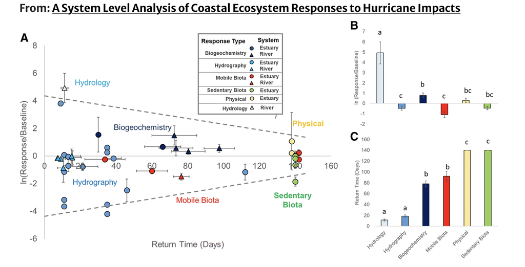

Resistance is calculated as the natural log of Response (Vdist) / Baseline (Vpre). Return is defined as the time when values return to Baseline values.

### Initial data visualization

These are our raw datasets that we will use to calculate our resistance and recovery metrics (y and x axes in Figure 2, respectively). We will not calculate these values for the control plot because there were no clear disturbances in trends.

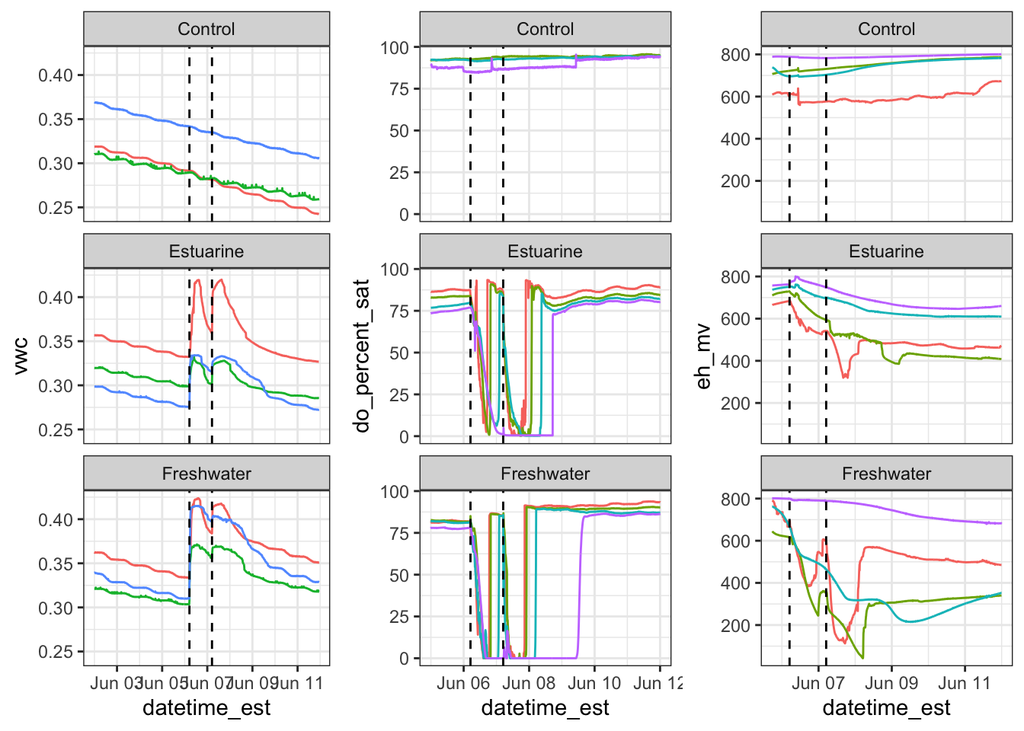

First step: label time-periods. We will calculate Vpre from period of data immediately before start of the first flood. Since redox sensors were installed later than DO (and VWC are permanently installed), we will trim all time-series to the last sensor installed prior to Vpre calculations:

```
## # A tibble: 22 × 4
## # Groups:   plot, depth [12]
##    plot      depth var            start_datetime
##    <chr>     <dbl> <chr>          <dttm>
##  1 Estuarine     5 do_percent_sat 2023-06-05 00:00:00
##  2 Estuarine     5 eh_mv          2023-06-05 17:40:00
##  3 Estuarine     5 vwc            2023-06-02 00:00:00
##  4 Estuarine    10 do_percent_sat 2023-06-05 00:00:00
##  5 Estuarine    15 eh_mv          2023-06-05 17:40:00
##  6 Estuarine    15 vwc            2023-06-02 00:00:00
##  7 Estuarine    20 do_percent_sat 2023-06-05 00:00:00
##  8 Estuarine    30 do_percent_sat 2023-06-05 00:00:00
##  9 Estuarine    30 eh_mv          2023-06-05 17:40:00
## 10 Estuarine    30 vwc            2023-06-02 00:00:00
## # ℹ 12 more rows
```

### Plots: assign time-periods

#### vwc

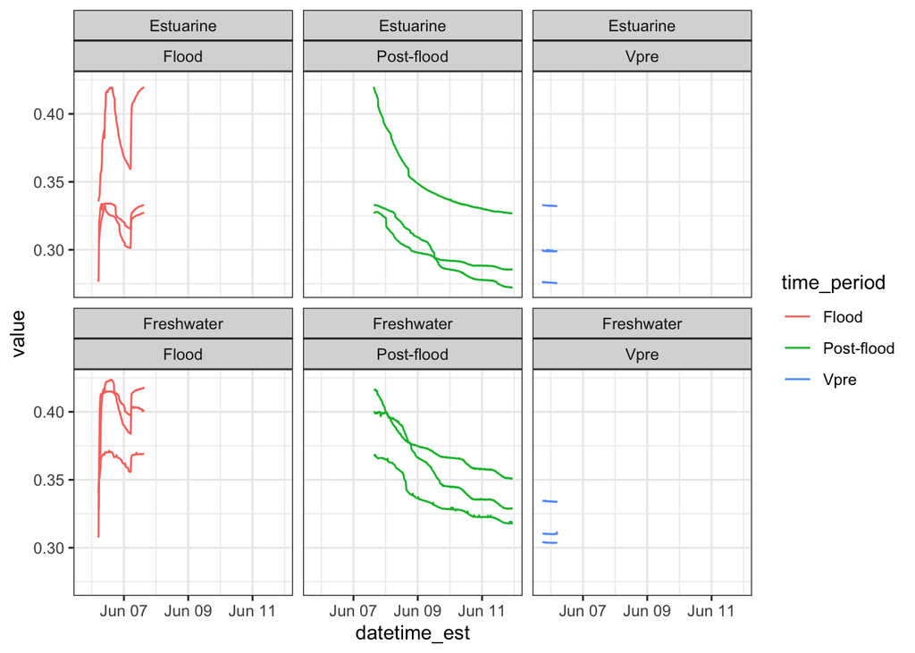

#### do_percent_sat

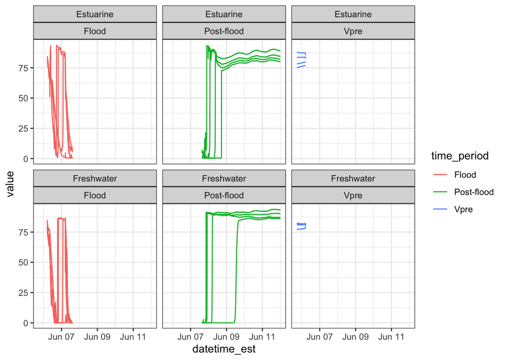

#### eh_mv

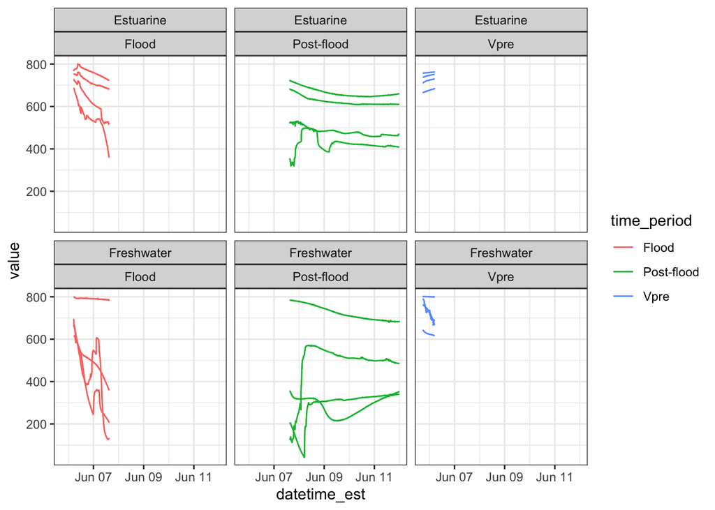

```
## # A tibble: 22 × 5
## # Groups:   plot, depth [12]
##    plot      depth var            vpre_mean  vpre_sd
##    <chr>     <dbl> <chr>              <dbl>    <dbl>
##  1 Estuarine     5 do_percent_sat    87.4   0.274
##  2 Estuarine     5 eh_mv            675.    5.48
##  3 Estuarine     5 vwc                0.332 0.000216
##  4 Estuarine    10 do_percent_sat    83.7   0.127
##  5 Estuarine    15 eh_mv            723.    5.24
##  6 Estuarine    15 vwc                0.299 0.000333
##  7 Estuarine    20 do_percent_sat    79.0   0.455
##  8 Estuarine    30 do_percent_sat    76.1   0.546
##  9 Estuarine    30 eh_mv            745.    4.11
## 10 Estuarine    30 vwc                0.276 0.000254
## # ℹ 12 more rows
```

### Plots: check increase/decrease and event_min/event_max

Circles are event maxima, and triangles are event minima

#### vwc

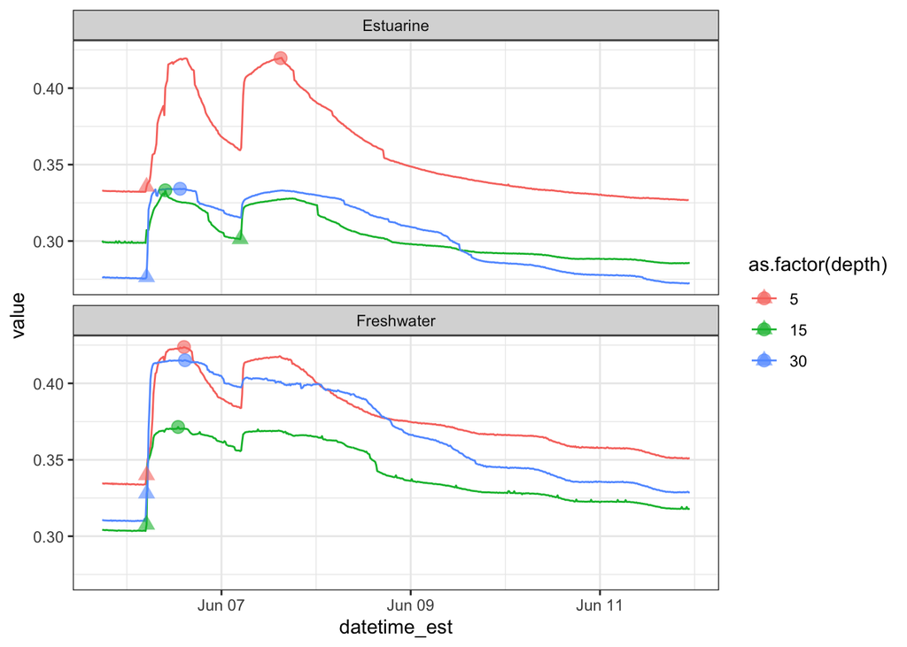

#### do_percent_sat

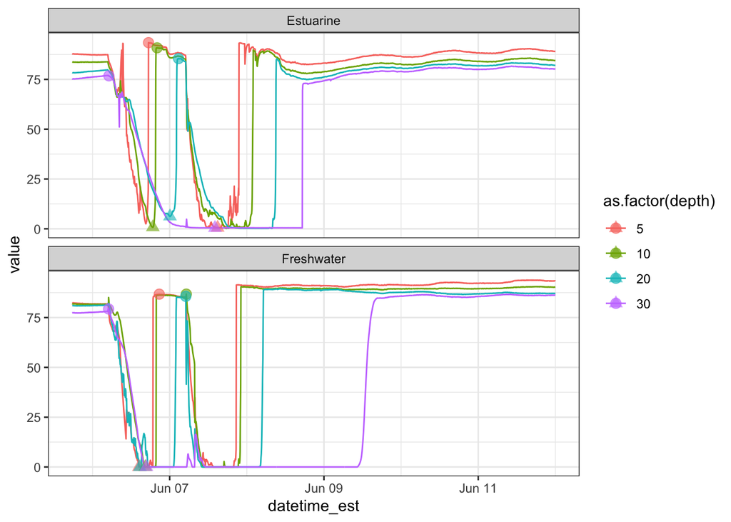

#### eh_mv

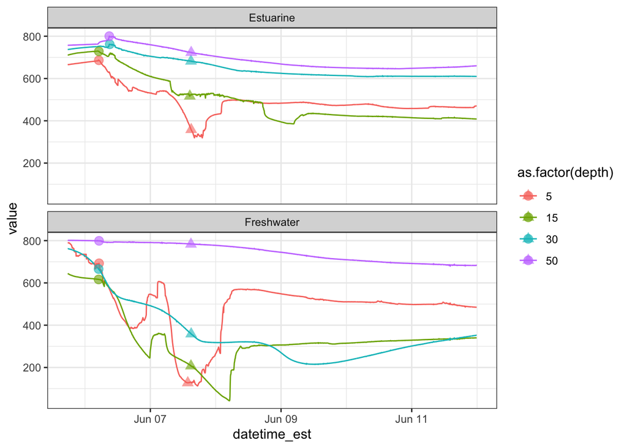

### Plots: look at log-response ratios calculations

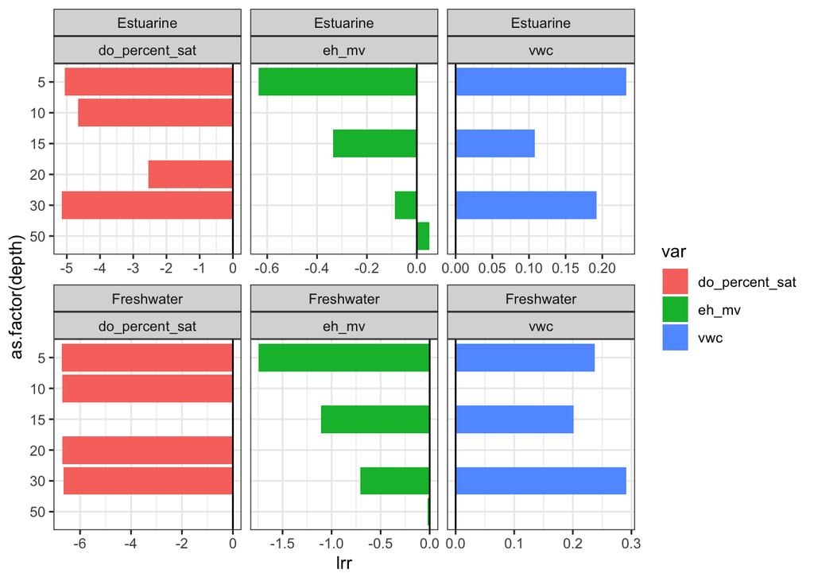

These are our resistance values, and the seem sensible. Because of the order-of-magnitude differences between our variables (0-100, 200-800, and 0.2-0.4), things are very different magnitudes of lrr. The TSLA way is to normalize prior, which allows us to apples-to-apples **between** plots, but removes the ability to compare between variables.

Next, let’s calculate our return times. This is going to be the first value after vdist that returns to baseline.

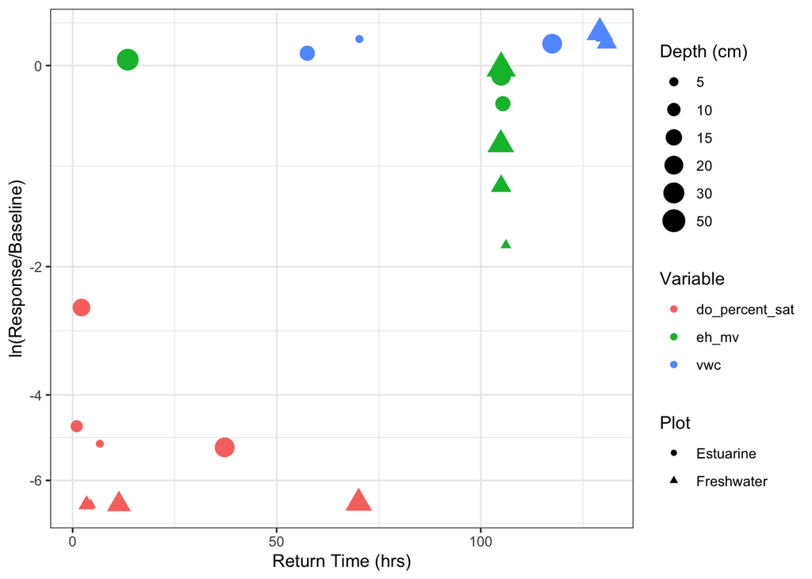